# Nutrient and chlorophyll analysis

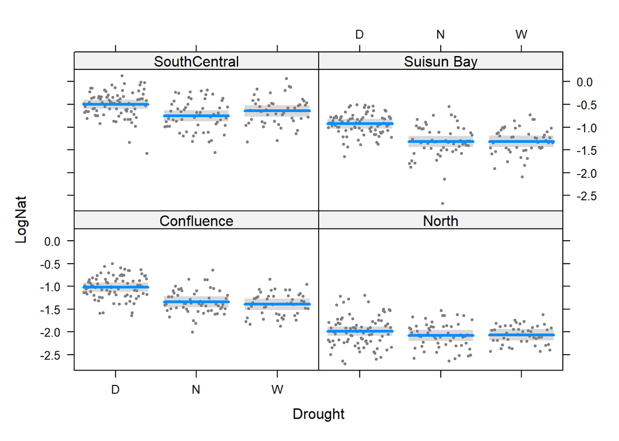

```r
visreg(Nat2, xvar = "Drought", by = "Region")
```

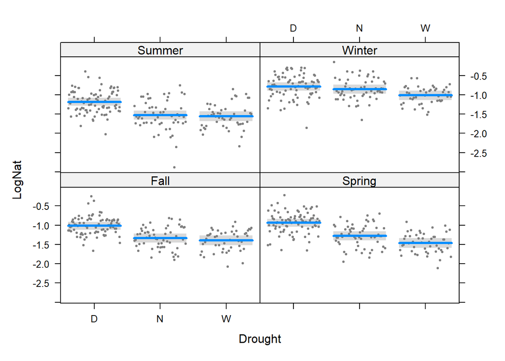

```r
visreg(Nat2, xvar = "Drought", by = "Season")
```

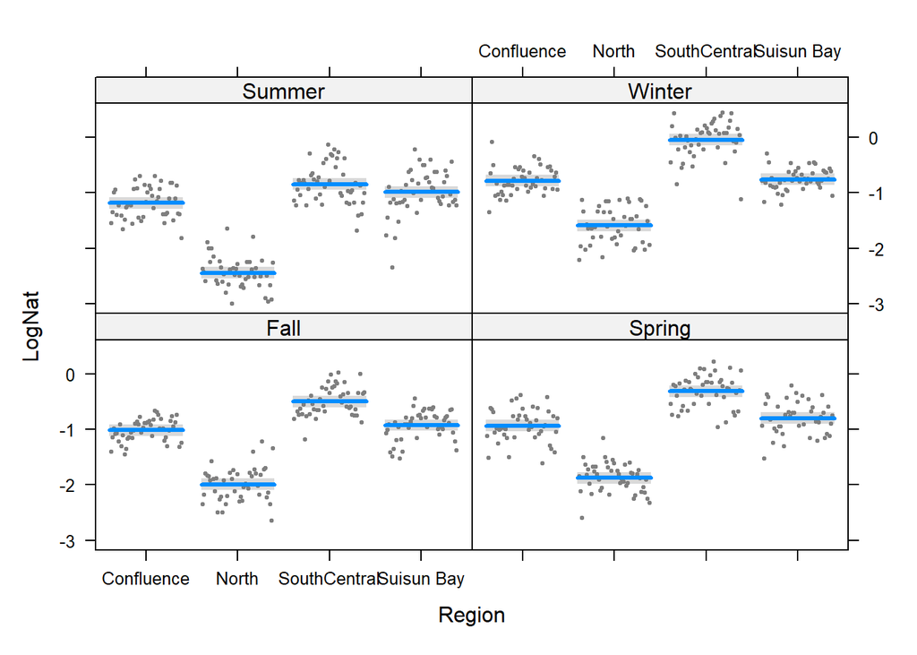

```r
visreg(Nat2, xvar = "Region", by = "Season")
```

```r
summary(Nat2)
```

```
##
## Call:
## lm(formula = LogNat ~ Drought * Region + Drought * Season + Region *
##     Season, data = Nitrate)
##
## Residuals:
##      Min       1Q   Median       3Q      Max
## -1.35923 -0.18500  0.00404  0.18472  0.79193
##
## Coefficients:
##                                  Estimate Std. Error t value Pr(>|t|)
## (Intercept)                     -1.017778   0.052548 -19.369  < 2e-16 ***
## DroughtN                        -0.320539   0.066241  -4.839 1.60e-06 ***
## DroughtW                        -0.377771   0.069503  -5.435 7.50e-08 ***
## RegionNorth                     -0.970893   0.068503 -14.173  < 2e-16 ***
## RegionSouthCentral               0.517744   0.068503   7.558 1.25e-13 ***
## RegionSuisun Bay                 0.091188   0.068512   1.331 0.183618
## SeasonSpring                     0.080514   0.068457   1.176 0.239937
## SeasonSummer                    -0.167968   0.068457  -2.454 0.014379 *
## SeasonWinter                     0.233185   0.069016   3.379 0.000768 ***
## DroughtN:RegionNorth             0.230551   0.070840   3.255 0.001189 **
## DroughtW:RegionNorth             0.303034   0.074546   4.065 5.33e-05 ***
## DroughtN:RegionSouthCentral      0.066926   0.070840   0.945 0.345101
## DroughtW:RegionSouthCentral      0.233552   0.074546   3.133 0.001801 **
## DroughtN:RegionSuisun Bay       -0.071598   0.070926  -1.009 0.313088
## DroughtW:RegionSuisun Bay       -0.009072   0.074371  -0.122 0.902950
## DroughtN:SeasonSpring           -0.021817   0.070753  -0.308 0.757904
## DroughtW:SeasonSpring           -0.149871   0.074206  -2.020 0.043790 *
## DroughtN:SeasonSummer           -0.023023   0.070753  -0.325 0.744976
## DroughtW:SeasonSummer            0.003852   0.074206   0.052 0.958618
## DroughtN:SeasonWinter            0.252282   0.070928   3.557 0.000400 ***
## DroughtW:SeasonWinter            0.146839   0.074898   1.961 0.050321 .
## RegionNorth:SeasonSpring         0.032742   0.084602   0.387 0.698858
## RegionSouthCentral:SeasonSpring  0.104571   0.084602   1.236 0.216847
## RegionSuisun Bay:SeasonSpring    0.048311   0.084602   0.571 0.568151
## RegionNorth:SeasonSummer        -0.281512   0.084602  -3.328 0.000921 ***
## RegionSouthCentral:SeasonSummer -0.176613   0.084602  -2.088 0.037188 *
## RegionSuisun Bay:SeasonSummer    0.105284   0.084602   1.244 0.213734
## RegionNorth:SeasonWinter         0.165879   0.085071   1.950 0.051580 .
## RegionSouthCentral:SeasonWinter  0.219130   0.085071   2.576 0.010199 *
## RegionSuisun Bay:SeasonWinter   -0.066024   0.085063  -0.776 0.437902
## ---
## Signif. codes:  0 '***' 0.001 '**' 0.01 '*' 0.05 '.' 0.1 ' ' 1
##
## Residual standard error: 0.29 on 718 degrees of freedom
##   (4 observations deleted due to missingness)
## Multiple R-squared:  0.8208, Adjusted R-squared:  0.8135
## F-statistic: 113.4 on 29 and 718 DF,  p-value: < 2.2e-16
```

```
## I bet you wanted to call this with just object[[1]] - use '[[]]' or which' if I'm wrong.
## See '? emm_list' for more information
```

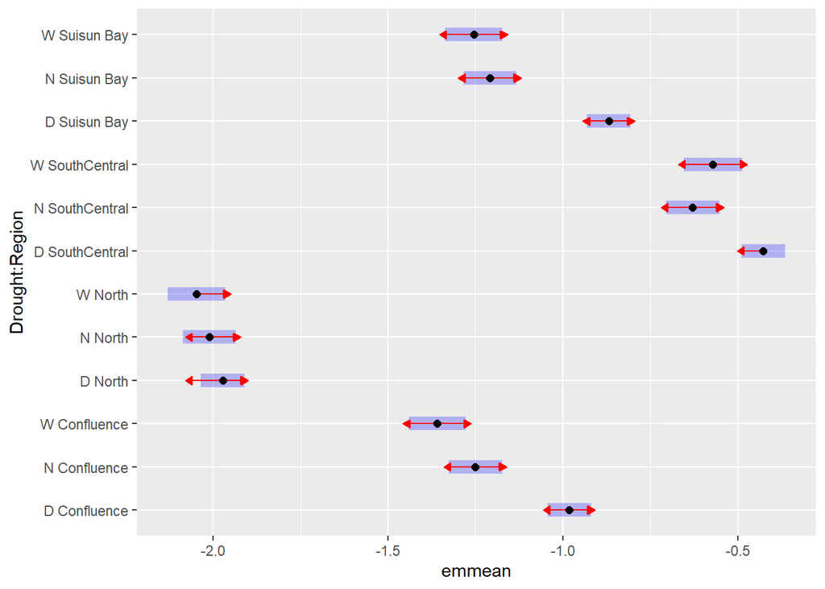

```r
pairsNN =  emmeans(Nat2, pairwise ~ Drought*Region)
plot(pairsNN, comparisons = T)
```

```
## I bet you wanted to call this with just object[[1]] - use '[[]]' or which' if I'm wrong.
## See '? emm_list' for more information
```

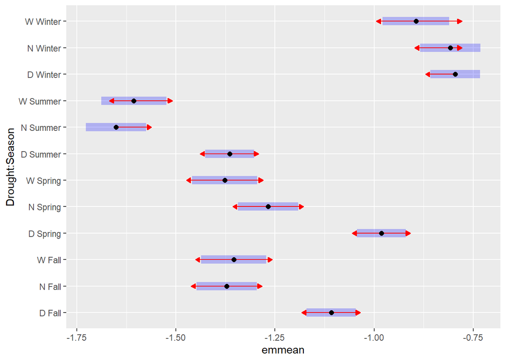

```r
pairsNN2 =  emmeans(Nat2, pairwise ~ Drought*Season)
plot(pairsNN2, comparisons = T)
```

OK, there is a big main effect of drought here, with droughts having higher nitrate, especially in the spring, summer and fall (no effect in the winter). If I’m reading this right, droughts mean increased nitrate in Suisun Bay and the Confluence, but not the Norht, whereas Ammonia increased in the North. Interesting.

## Ortho-phosphate

Phosphate Although phosphate concentration did not change over the long term (Table 2), there was substantial variability of phosphate concentration as an early period of increase during the 1980s, peak concentrations in the early 1990s (Fig. 3) followed by a period of significant decrease (Fig. 5B). Records of phosphorus loading from the Sacramento Regional Wastewater Treatment Facility are not available during the early era of phosphate increase. However, measurements since 1987 showed a steep decrease in wastewater TP loading in the early 1990s that paralleled the downstream phosphate decrease at Sta. D8. This suggests that wastewater effluent is a significant source of phosphorus, as well as ammonium nitrogen, to the upper estuary. The best-fitting regression model (Table 4) explained 73% of annual-mean phosphate concentration as a negative function of Outflow (effect size = −0.74) and a positive function of wastewater TP loading (effect size = +0.25), similar to model results for ammonium. Relative to theOutflow effect, the effect of wastewater TP loading was smaller than the effect of ammonium loading (Table 4). This suggests that the wastewater enrichment of riverine phosphate is smaller than its enrichment of riverine ammonium. The parallel steep declines of phosphorus loading and concentrations in the estuary during the 1990s (Fig. 3) occurred after it became evident that phosphorus enrichment was degrading water quality of U.S. lakes and rivers. State bans on phosphorus-containing detergents grew in the 1970s and 1980s, and by 1994 the manufacture of phosphorus-based detergents ended (Litke 1999). Thus, the oscillating patterns of phosphate concentrations in San Francisco Bay (and other estuaries and lakes) include eras of increase associated with population growth (Jassby 2008) and decrease after policies were implemented to remove phosphorus from household detergents.

```r
Phos <- raw_nutr_1975_2021 %>%
  # Remove NA values in DissNitrate
  tidyr::drop_na(DissOrthophos) %>%
  # Replace <RL values with random value
  drt_replace_rl(DissOrthophos, DissOrthophos_Sign) %>%
  # Calculate seasonal-regional averages
  drt_avg_data(DissOrthophos, avg_type = "both", month_na = "relaxed") %>%
  # Add year assignments
  drt_add_yr_assign() %>%
  mutate(YearType = factor(YearType, levels = c("Critical", "Dry", "Below Normal",
                                                "Above Normal", "Wet")),
         LogPhos = log(DissOrthophos))
```

plots

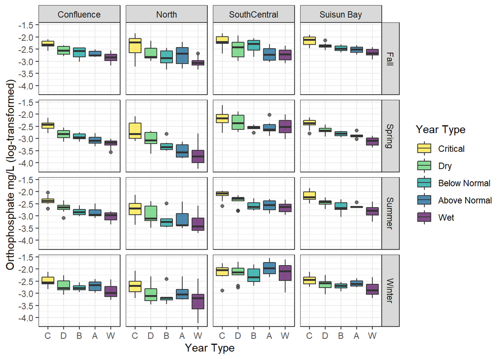

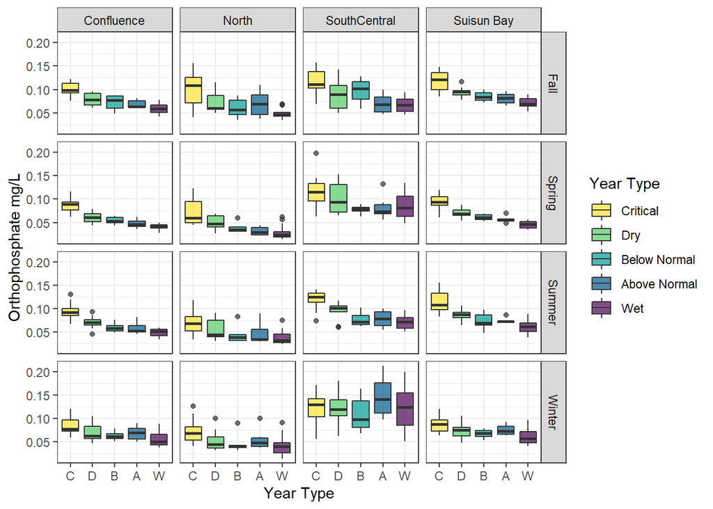

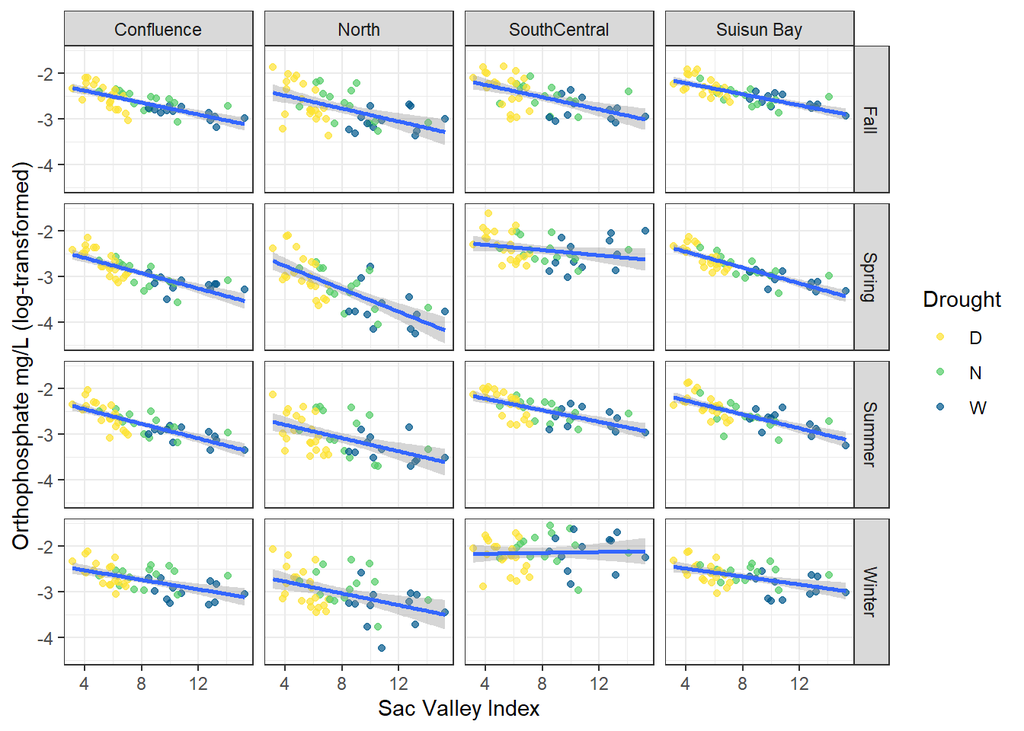

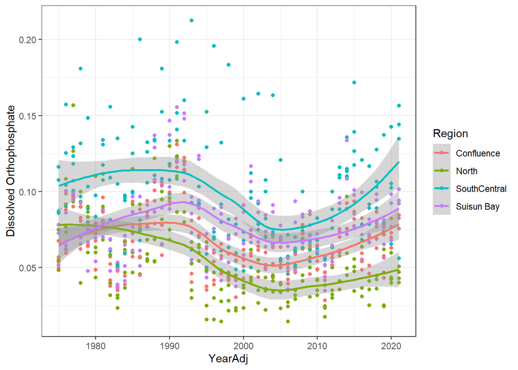

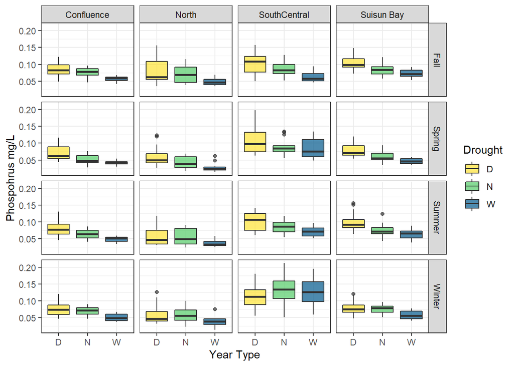

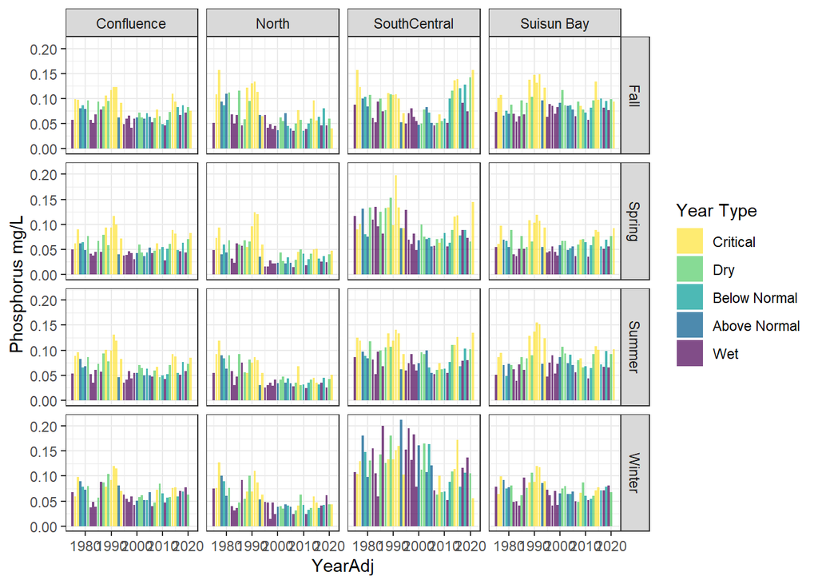

Huh. Cloern didn’t see any overal trends in Phosphorus, but I hink that’s a pattern. Anyway.

Log-transforming phosphorus didn’t look quite as nice as nitrogen and ammonium. Square-root transformation looked better, but the residuals acutlaly looked pretty good for both, so I just stuck with the log-transformation to keep it consistent.

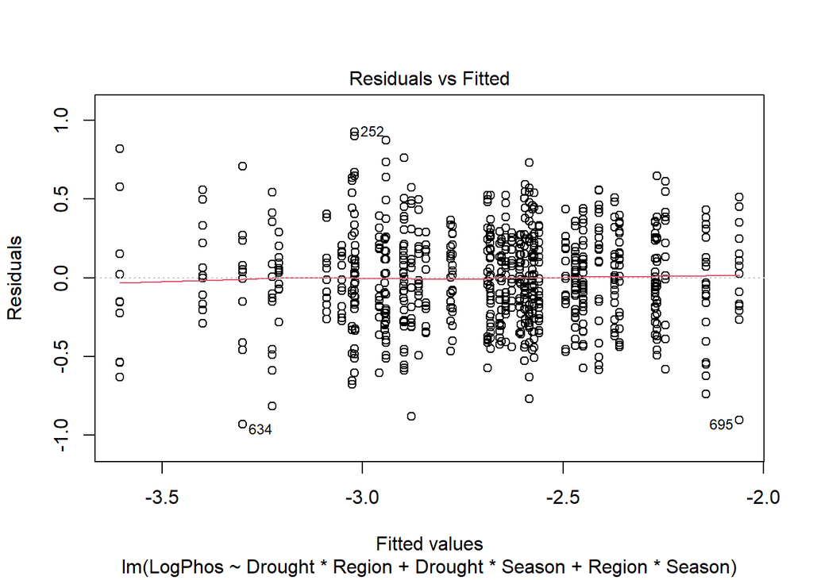

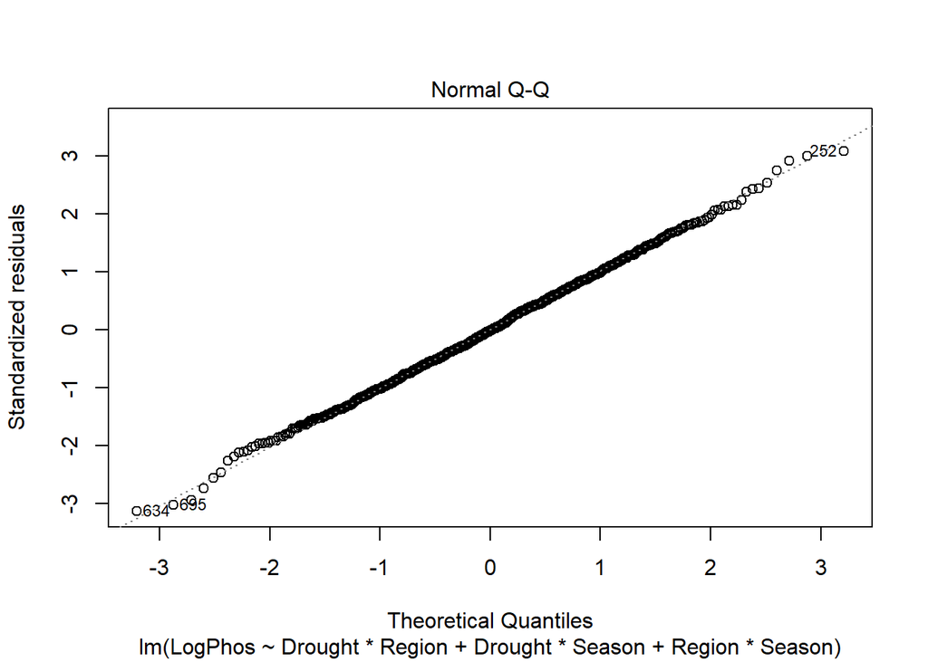

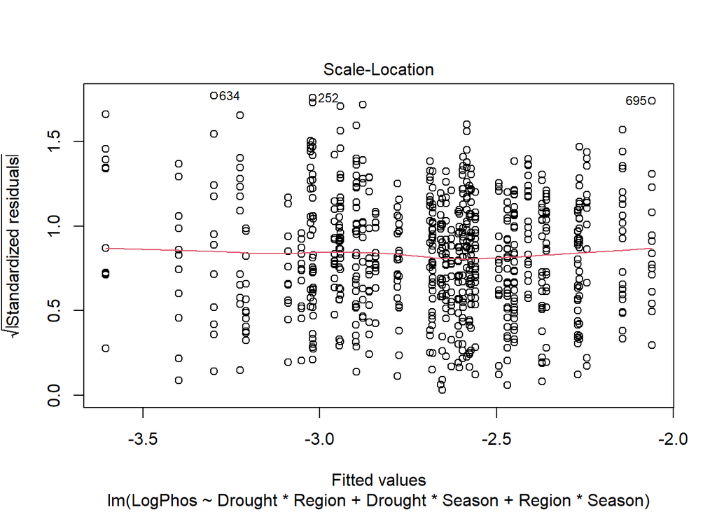

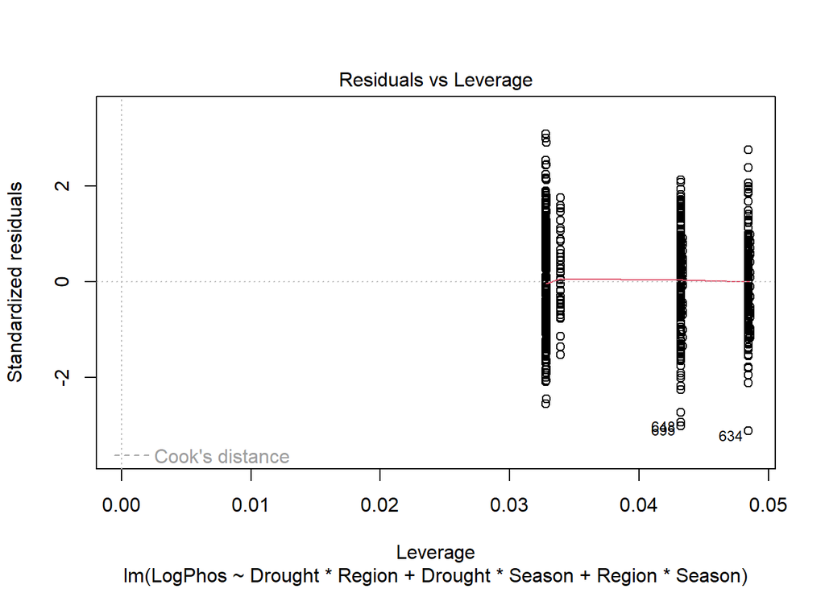

```r
Phos2 = lm(LogPhos ~Drought*Region + Drought*Season + Region*Season, data = Phos)
plot(Phos2)
```

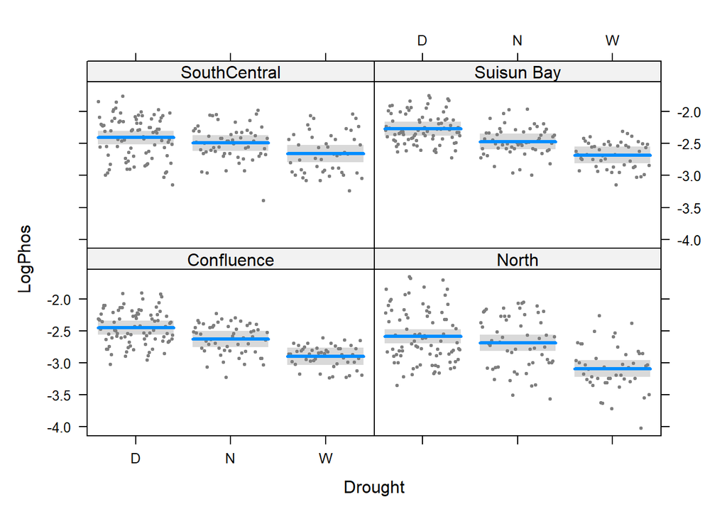

```r
visreg(Phos2, xvar = "Drought", by = "Region")
```

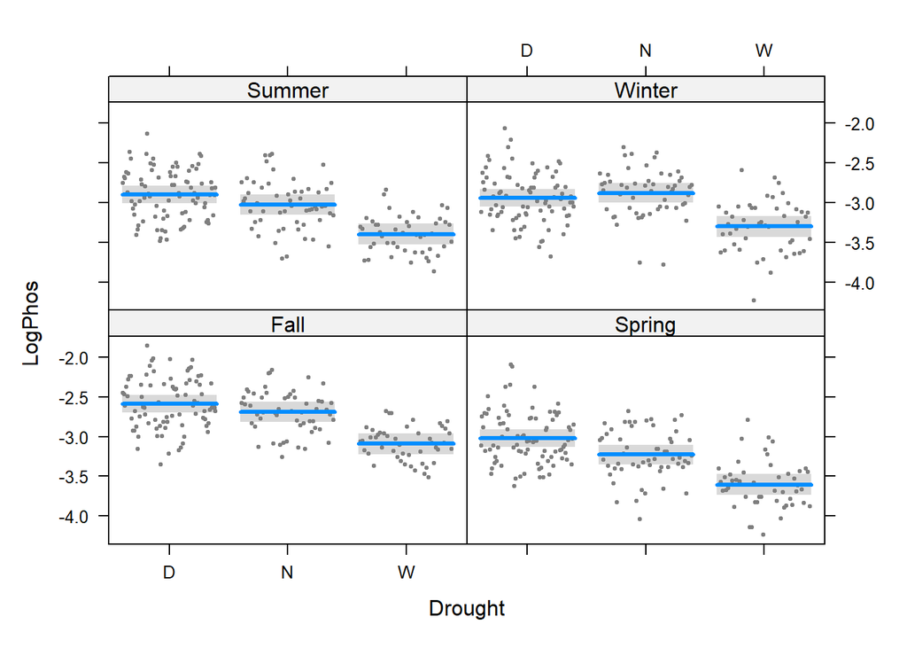

```r
visreg(Phos2, xvar = "Drought", by = "Season")
```

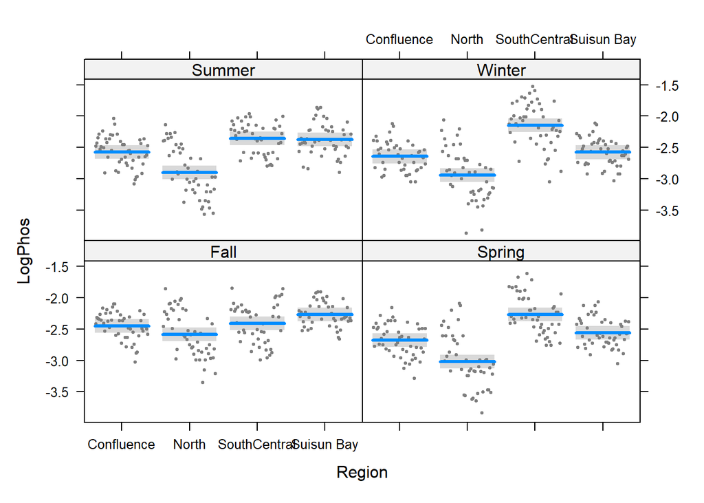

```r
visreg(Phos2, xvar = "Region", by = "Season")
```

```r
summary(Phos2)
```

```
##
## Call:
## lm(formula = LogPhos ~ Drought * Region + Drought * Season +
##     Region * Season, data = Phos)
##
## Residuals:
##      Min       1Q   Median       3Q      Max
## -0.93271 -0.20412 -0.00449  0.20644  0.92730
##
## Coefficients:
##                                  Estimate Std. Error t value Pr(>|t|)
## (Intercept)                     -2.449115   0.055383 -44.221  < 2e-16 ***
## DroughtN                        -0.178141   0.069819  -2.551  0.01093 *
## DroughtW                        -0.448946   0.073221  -6.131 1.44e-09 ***
## RegionNorth                     -0.134761   0.072184  -1.867  0.06232 .
## RegionSouthCentral               0.039391   0.072184   0.546  0.58544
## RegionSuisun Bay                 0.179507   0.072213   2.486  0.01315 *
## SeasonSpring                    -0.230832   0.072155  -3.199  0.00144 **
## SeasonSummer                    -0.123505   0.072155  -1.712  0.08739 .
## SeasonWinter                    -0.194480   0.072703  -2.675  0.00764 **
## DroughtN:RegionNorth             0.073187   0.074666   0.980  0.32732
## DroughtW:RegionNorth            -0.056897   0.078302  -0.727  0.46768
## DroughtN:RegionSouthCentral      0.094017   0.074666   1.259  0.20838
## DroughtW:RegionSouthCentral      0.200607   0.078302   2.562  0.01061 *
## DroughtN:RegionSuisun Bay       -0.021768   0.074757  -0.291  0.77099
## DroughtW:RegionSuisun Bay        0.036316   0.078388   0.463  0.64330
## DroughtN:SeasonSpring           -0.100304   0.074575  -1.345  0.17904
## DroughtW:SeasonSpring           -0.080454   0.078214  -1.029  0.30400
## DroughtN:SeasonSummer           -0.025133   0.074575  -0.337  0.73621
## DroughtW:SeasonSummer            0.003306   0.078214   0.042  0.96630
## DroughtN:SeasonWinter            0.167743   0.074759   2.244  0.02515 *
## DroughtW:SeasonWinter            0.147396   0.078390   1.880  0.06047 .
## RegionNorth:SeasonSpring        -0.205459   0.089172  -2.304  0.02150 *
## RegionSouthCentral:SeasonSpring  0.374907   0.089172   4.204 2.95e-05 ***
## RegionSuisun Bay:SeasonSpring   -0.059016   0.089172  -0.662  0.50829
## RegionNorth:SeasonSummer        -0.188936   0.089172  -2.119  0.03445 *
## RegionSouthCentral:SeasonSummer  0.173622   0.089172   1.947  0.05192 .
## RegionSuisun Bay:SeasonSummer    0.021605   0.089172   0.242  0.80863
## RegionNorth:SeasonWinter        -0.162972   0.089416  -1.823  0.06878 .
## RegionSouthCentral:SeasonWinter  0.460494   0.089416   5.150 3.37e-07 ***
## RegionSuisun Bay:SeasonWinter   -0.112532   0.089658  -1.255  0.20984
## ---
## Signif. codes:  0 '***' 0.001 '**' 0.01 '*' 0.05 '.' 0.1 ' ' 1
##
## Residual standard error: 0.3057 on 720 degrees of freedom
##   (2 observations deleted due to missingness)
## Multiple R-squared:  0.5296, Adjusted R-squared:  0.5107
## F-statistic: 27.96 on 29 and 720 DF,  p-value: < 2.2e-16
```

```
## I bet you wanted to call this with just object[[1]] - use '[[]]' or which' if I'm wrong.
## See '? emm_list' for more information
```

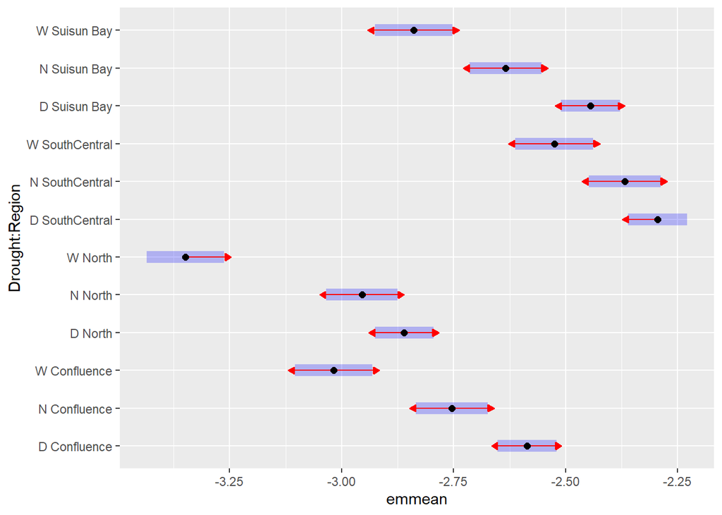

```r
pairsP =  emmeans(Phos2, pairwise ~ Drought*Region)
plot(pairsP, comparisons = T)
```

```
## NOTE: Results may be misleading due to involvement in interactions
## I bet you wanted to call this with just object[[1]] - use '[[]]' or which' if I'm wrong.
## See '? emm_list' for more information
```

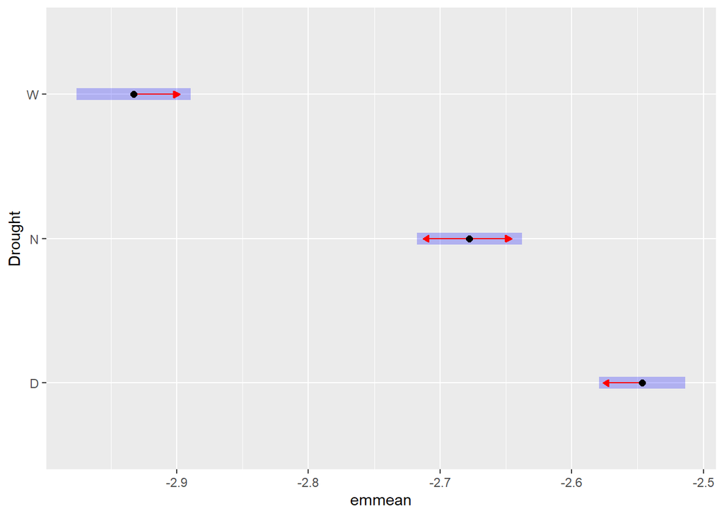

```r
plot(emmeans(Phos2, pairwise ~ Drought), comparisons = T)
```

For phosphorus, the story is still really the main effect of drought. Lower Phosphorus in wet years.

## Chlorophyll

This is what Cloern has to say:

Chl a Phytoplankton biomass in estuaries is regulated by riverdriven transport processes and the balance between growth and grazing rates. Chl a at Sta. D8 decreased abruptly in 1987 (Table 3), and the largest declines occurred in summer—May through September (Fig. 6C). The best-fitting model of summer Chl a had an interactive effect between Outflow and clam abundance. This interaction was expected because the relationship between Chl a and Outflow changed after the Potamocorbula introduction (Jassby 2008). Most (80%) of that variability was associated with Outflow and clam abundance treated as a categorical variable (Fig. 8B). No other variables, such as temperature, turbidity (Secchi depth), nutrient concentrations, or loadings had comparable effects on summer Chl a. Summer phytoplankton blooms occurred regularly in this region of the estuary during the 1970s and 1980s. These were attributed to the accumulation of phytoplankton cells withinan estuarine turbidity maximum that was positioned in Suisun Bay (Sta. D8) when Outflow was in the range 100–350 m3 s−1 (Cloern et al. 1983). Thus, flow-phytoplankton relationships were established early in the study of San Francisco Bay. Observations made over the subsequent 3+ decades confirm that summer Chl a decreases when Outflow exceeds about200–300 m3 s−1 (Fig. 8B), primarily through its effect on residence time (Jassby 2008). A summer bloom did not develop in 1977, a year of extreme drought when salinity increased high enough that the upper estuary was colonized by marine benthic filter feeders including M. arenaria (Nichols 1985). The 1977 anomaly was the first evidence that bivalve grazing can suppress blooms in this estuary. Summer blooms disappeared completely after P. amurensis became established as a permanent resident in 1987. The regression model (Table 4) shows that the effect of clam presence was large (−13.1) compared to the outflow effect (−2.5). The nearly fourfold loss of phytoplankton biomass (Table 2) and production restructured biological communities and altered nutrient dynamics, establishing what has become an iconic example of abrupt disturbance by the introduction of a non-native species (Cloern and Jassby 2012). Regression models allow us to compare the effects of that human disturbance with the effect of varying freshwater inflow.

```r
#replace values below the reporting limit
ChlaA <- raw_chla_1975_2021 %>%
  # Remove NA values in DissAmmonia
  tidyr::drop_na(Chlorophyll) %>%
  # Replace <RL values with random value
  drt_replace_rl(Chlorophyll, Chlorophyll_Sign) %>%
   # Calculate seasonal-regional averages
  drt_avg_data(Chlorophyll, avg_type = "both", month_na = "relaxed") %>%
  # Add year assignments
  drt_add_yr_assign() %>%
  mutate(YearType = factor(YearType, levels = c("Critical", "Dry", "Below Normal",
                                                "Above Normal", "Wet")),
         LogChl = log(Chlorophyll))
```

Now some plots

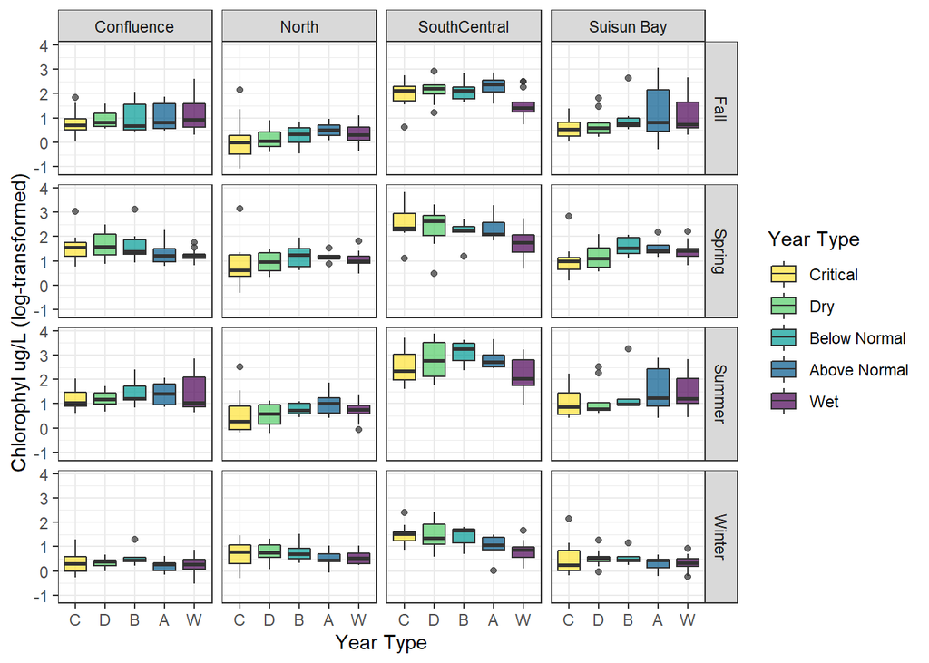

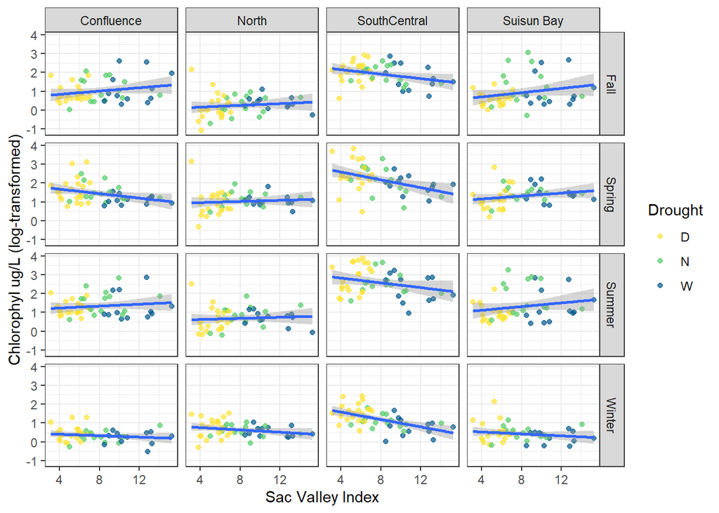

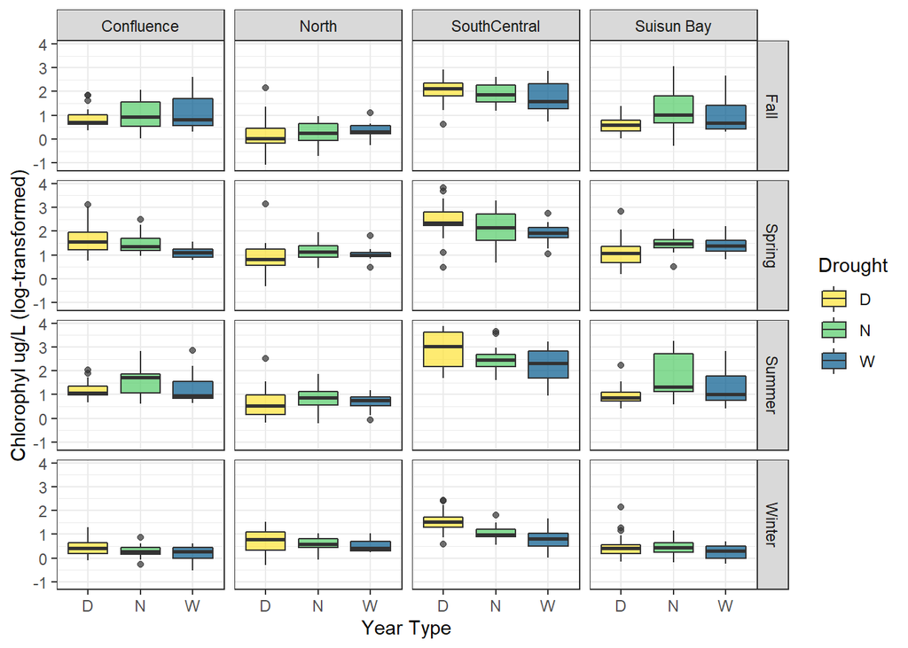

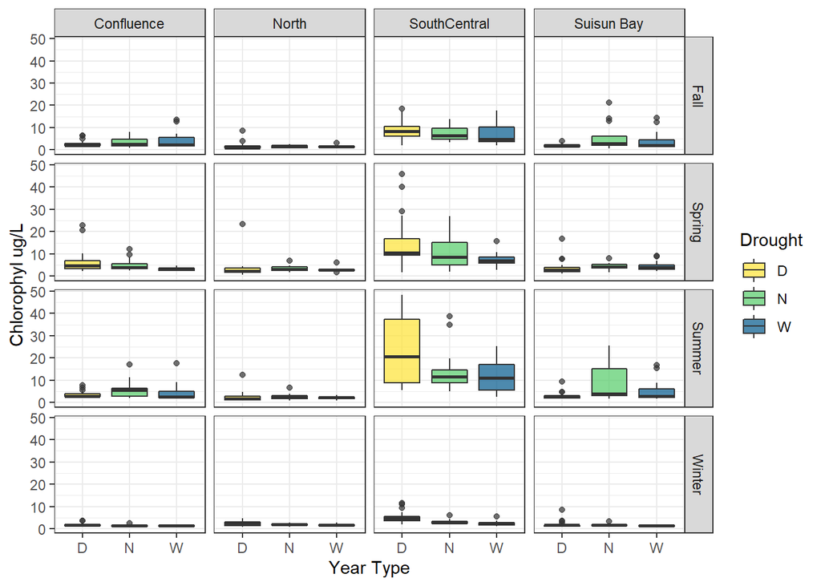

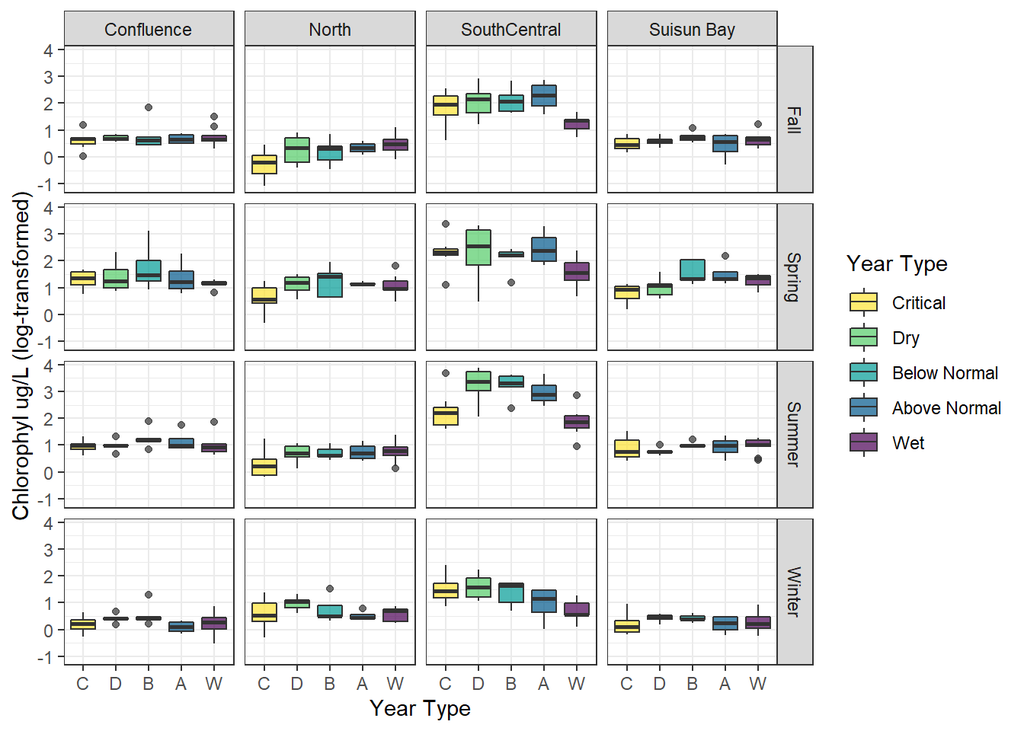

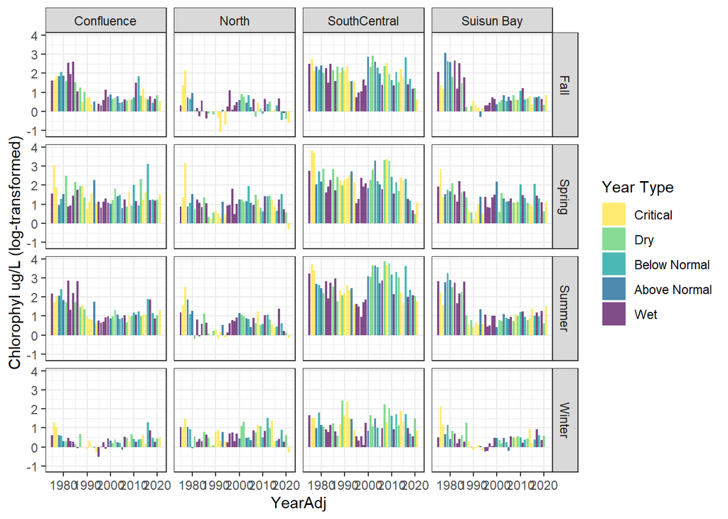

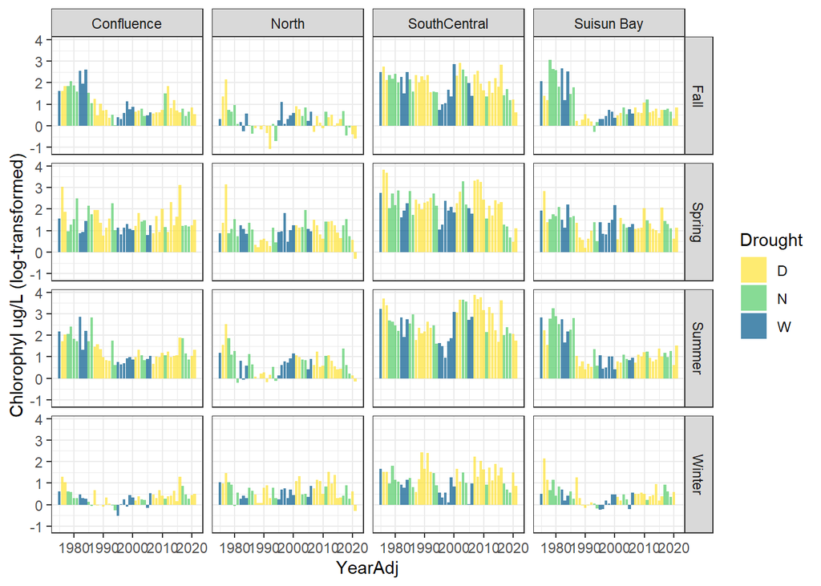

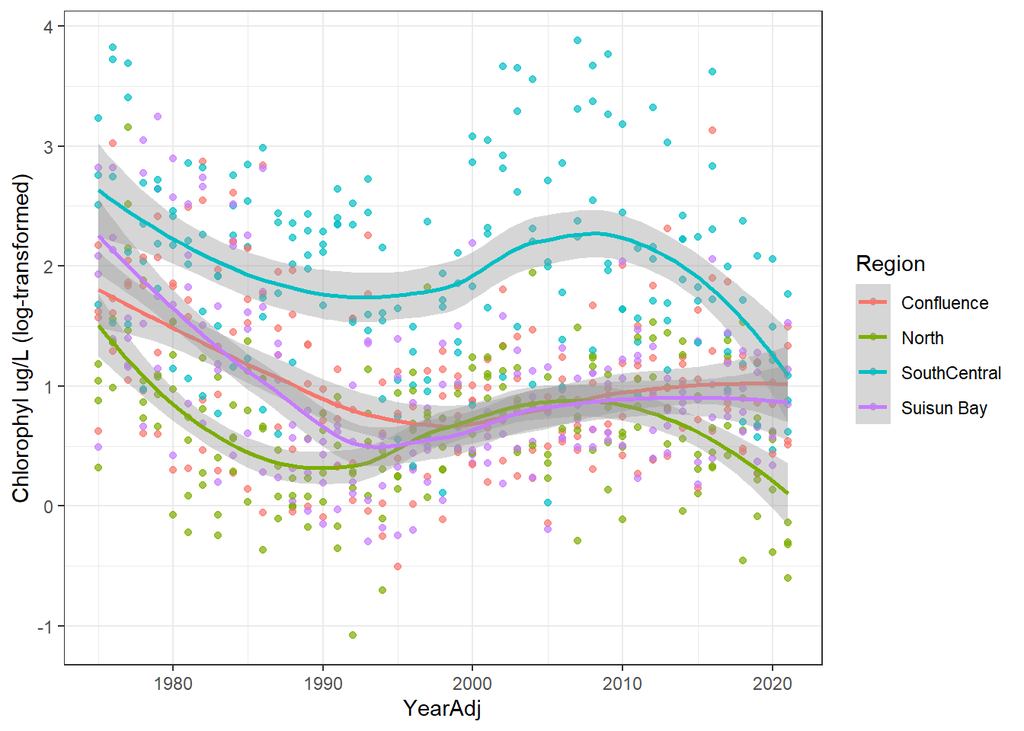

And now for some statistics

```r
Chl1 = lm(LogChl ~ Drought*Region+ Drought*Season + Region*Season, data = ChlaA)
summary(Chl1)
```

```
##
## Call:
## lm(formula = LogChl ~ Drought * Region + Drought * Season + Region *
##     Season, data = ChlaA)
##
## Residuals:
##      Min       1Q   Median       3Q      Max
## -2.00655 -0.35504 -0.05465  0.30528  2.13776
##
## Coefficients:
##                                 Estimate Std. Error t value Pr(>|t|)
## (Intercept)                      0.91764    0.10249   8.953  < 2e-16 ***
## DroughtN                         0.19001    0.12916   1.471 0.141680
## DroughtW                         0.14501    0.13546   1.070 0.284753
## RegionNorth                     -0.79566    0.13359  -5.956 4.03e-09 ***
## RegionSouthCentral               1.15782    0.13359   8.667  < 2e-16 ***
## RegionSuisun Bay                -0.27506    0.13364  -2.058 0.039926 *
## SeasonSpring                     0.57644    0.13359   4.315 1.82e-05 ***
## SeasonSummer                     0.34730    0.13359   2.600 0.009518 **
## SeasonWinter                    -0.41887    0.13364  -3.134 0.001792 **
## DroughtN:RegionNorth             0.01740    0.13806   0.126 0.899767
## DroughtW:RegionNorth             0.13771    0.14480   0.951 0.341906
## DroughtN:RegionSouthCentral     -0.39398    0.13806  -2.854 0.004447 **
## DroughtW:RegionSouthCentral     -0.45855    0.14480  -3.167 0.001607 **
## DroughtN:RegionSuisun Bay        0.36882    0.13823   2.668 0.007800 **
## DroughtW:RegionSuisun Bay        0.30289    0.14496   2.089 0.037020 *
## DroughtN:SeasonSpring           -0.17382    0.13806  -1.259 0.208438
## DroughtW:SeasonSpring           -0.29777    0.14480  -2.056 0.040105 *
## DroughtN:SeasonSummer            0.07133    0.13806   0.517 0.605556
## DroughtW:SeasonSummer           -0.17036    0.14480  -1.176 0.239784
## DroughtN:SeasonWinter           -0.40058    0.13823  -2.898 0.003872 **
## DroughtW:SeasonWinter           -0.52440    0.14496  -3.617 0.000318 ***
## RegionNorth:SeasonSpring         0.32153    0.16509   1.948 0.051850 .
## RegionSouthCentral:SeasonSpring -0.17992    0.16509  -1.090 0.276143
## RegionSuisun Bay:SeasonSpring   -0.06410    0.16509  -0.388 0.697919
## RegionNorth:SeasonSummer         0.10807    0.16509   0.655 0.512914
## RegionSouthCentral:SeasonSummer  0.33312    0.16509   2.018 0.043976 *
## RegionSuisun Bay:SeasonSummer    0.05726    0.16509   0.347 0.728797
## RegionNorth:SeasonWinter         1.06491    0.16509   6.451 2.04e-10 ***
## RegionSouthCentral:SeasonWinter -0.04549    0.16509  -0.276 0.782983
## RegionSuisun Bay:SeasonWinter    0.18047    0.16554   1.090 0.276010
## ---
## Signif. codes:  0 '***' 0.001 '**' 0.01 '*' 0.05 '.' 0.1 ' ' 1
##
## Residual standard error: 0.5659 on 721 degrees of freedom
##   (1 observation deleted due to missingness)
## Multiple R-squared:  0.5882, Adjusted R-squared:  0.5716
## F-statistic: 35.51 on 29 and 721 DF,  p-value: < 2.2e-16
```

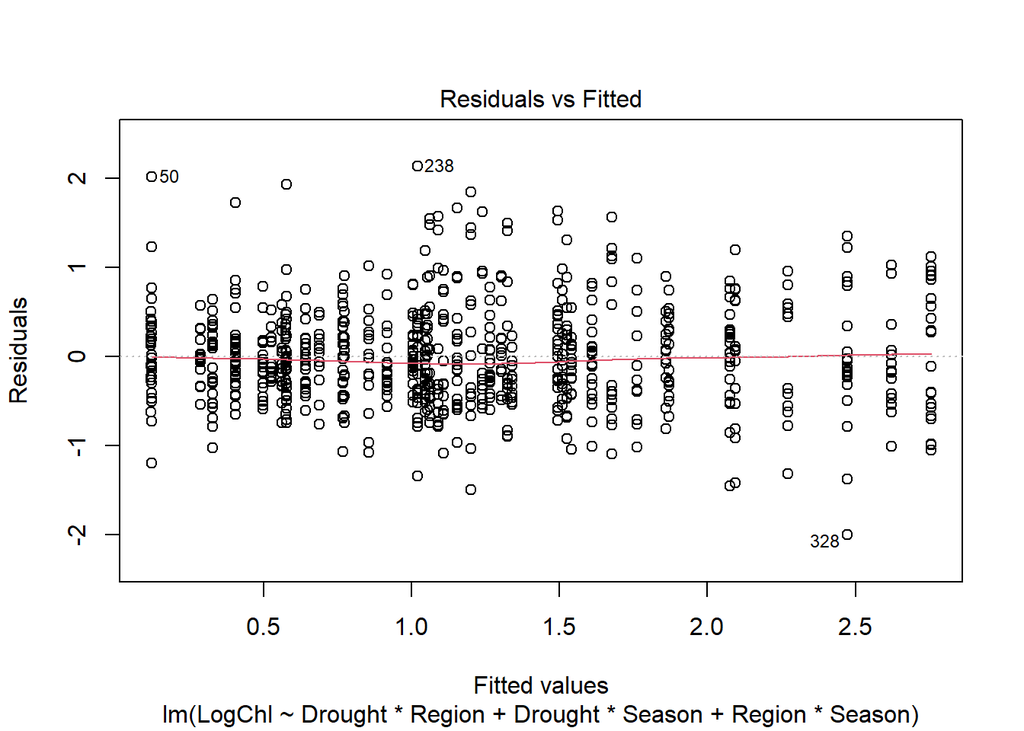

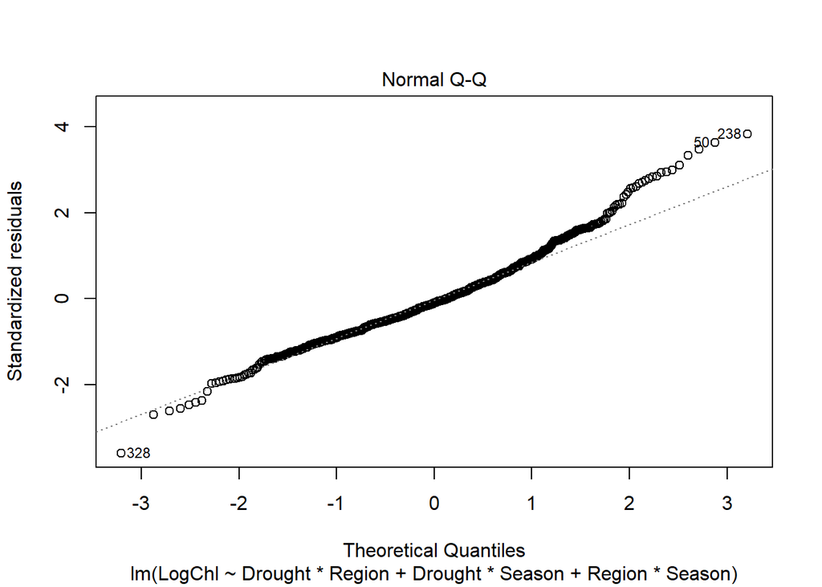

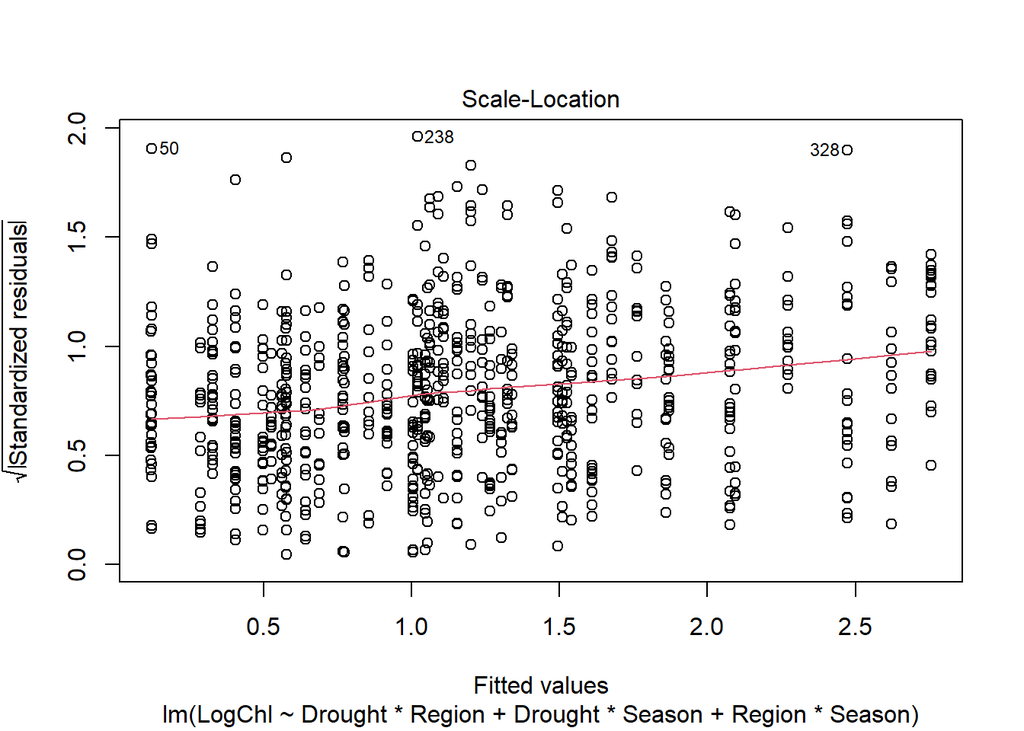

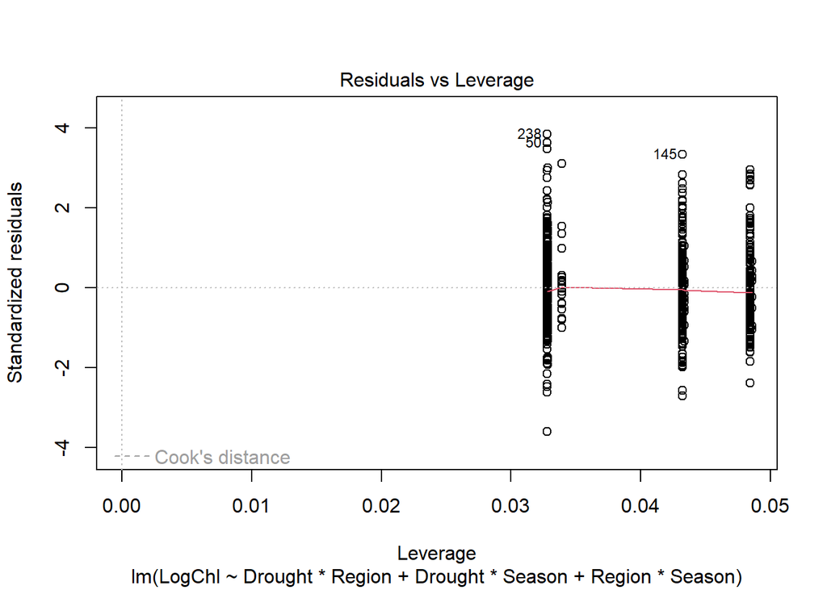

```r
plot(Chl1)
```

```r
library(car)
```

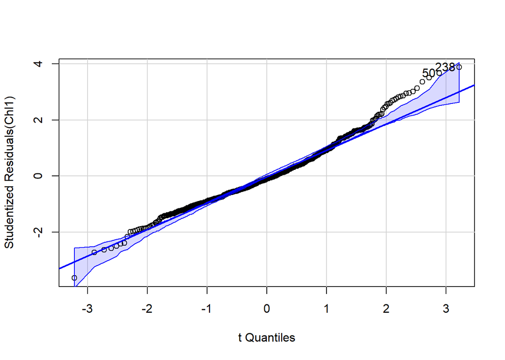

```
## [1]  50 238
```

```r
qqPlot(Chl1)
```

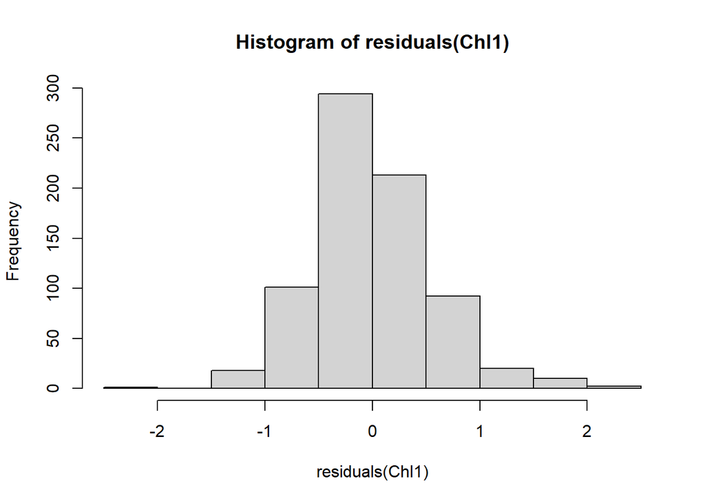

```r
hist(residuals(Chl1))
```

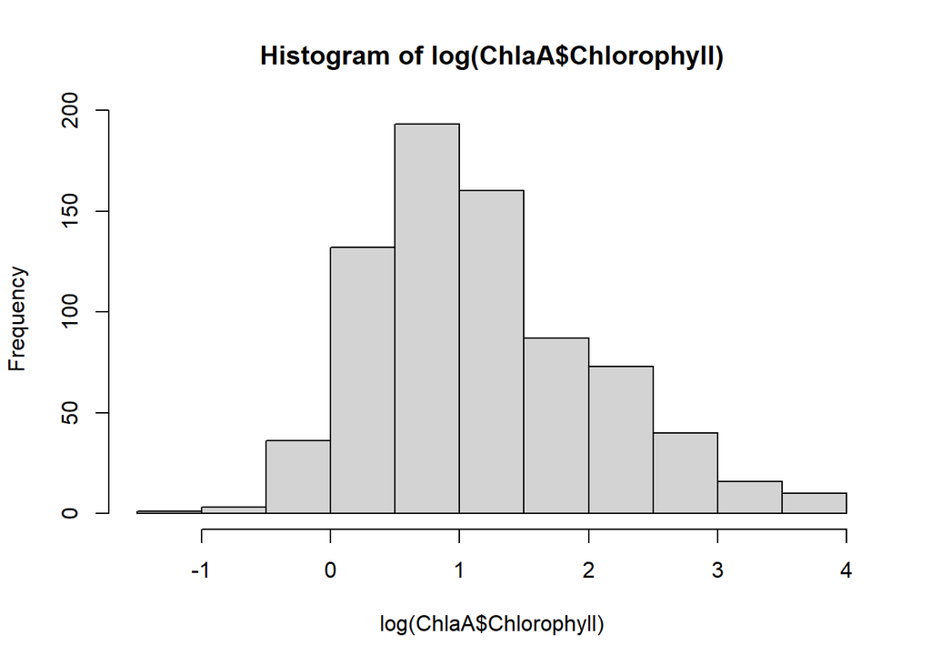

```r
#BLEH

hist(log(ChlaA$Chlorophyll))
```

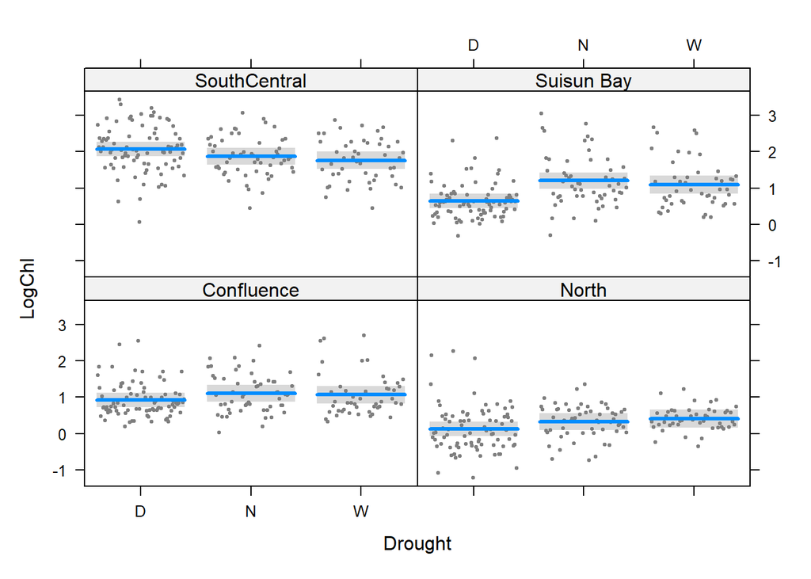

```r
visreg(Chl1, xvar = "Drought", by = "Region")
```

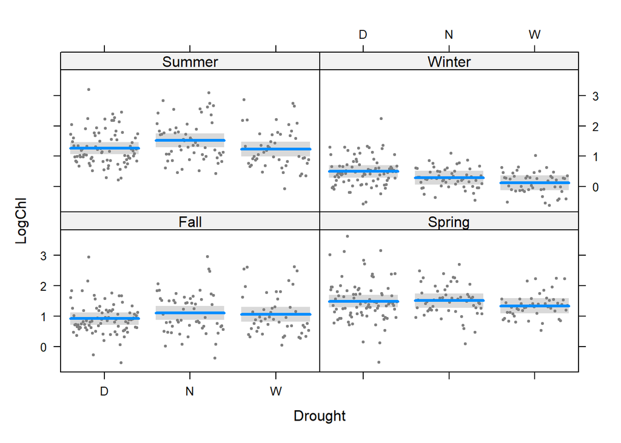

```r
visreg(Chl1, xvar = "Drought", by = "Season")
```

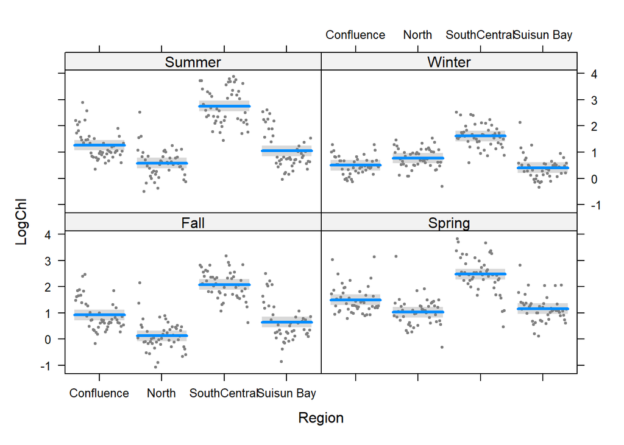

```r
visreg(Chl1, xvar = "Region", by = "Season")
```

```
## I bet you wanted to call this with just object[[1]] - use '[[]]' or which' if I'm wrong.
## See '? emm_list' for more information
```

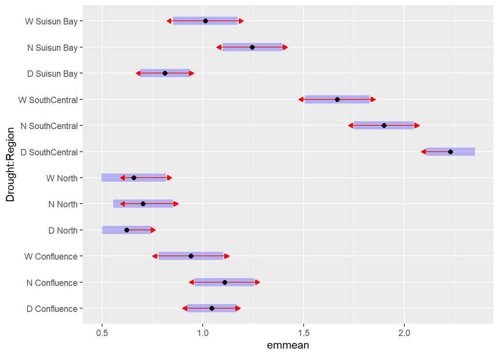

```r
pairsC =  emmeans(Chl1, pairwise ~ Drought*Region)
plot(pairsC, comparisons = T)
```

```
## I bet you wanted to call this with just object[[1]] - use '[[]]' or which' if I'm wrong.
## See '? emm_list' for more information
```

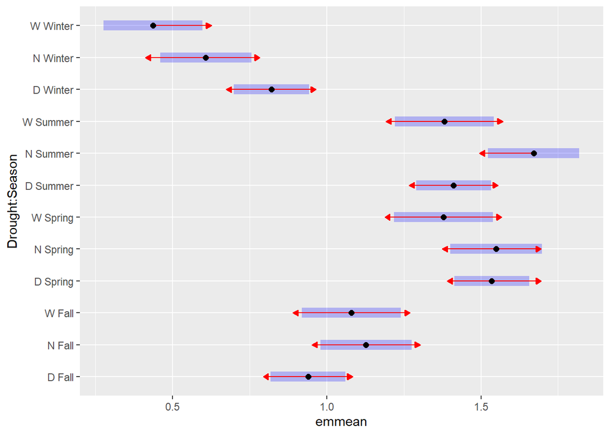

```r
pairsC2 =  emmeans(Chl1, pairwise ~ Drought*Season)
plot(pairsC2, comparisons = T)
```

Yup. Chlorophyll still refuses to be interesting. It’s also not quite meeting my linear regression assumptions. Am I allowed to take the square-root of a log? Probably not. Maybe a gamma distribution? Or just go to brms?

I need to get Sam to check my work on this. Is lognormal appropriate?

```r
library(brms)
chlb = brm(Chlorophyll ~ Region*Drought+ Season*Drought + Region*Season, data = ChlaA,
           family = lognormal, backend = "cmdstanr", silent = 2)
```

[output not shown]

[output cut: 43 more lines]

[output not shown]

```r
summary(chlb)
```

```
##  Family: lognormal
##   Links: mu = identity; sigma = identity
## Formula: Chlorophyll ~ Region * Drought + Season * Drought + Region * Season
##    Data: ChlaA (Number of observations: 751)
##   Draws: 4 chains, each with iter = 2000; warmup = 1000; thin = 1;
##          total post-warmup draws = 4000
##
## Population-Level Effects:
##                                 Estimate Est.Error l-95% CI u-95% CI Rhat
## Intercept                           0.92      0.10     0.73     1.12 1.00
## RegionNorth                        -0.80      0.13    -1.05    -0.55 1.00
## RegionSouthCentral                  1.15      0.13     0.90     1.40 1.00
## RegionSuisunBay                    -0.28      0.13    -0.54    -0.02 1.00
## DroughtN                            0.18      0.13    -0.07     0.43 1.00
## DroughtW                            0.14      0.14    -0.13     0.40 1.00
## SeasonSpring                        0.58      0.13     0.32     0.84 1.00
## SeasonSummer                        0.35      0.14     0.08     0.62 1.00
## SeasonWinter                       -0.42      0.13    -0.67    -0.16 1.00
## RegionNorth:DroughtN                0.03      0.14    -0.24     0.29 1.00
## RegionSouthCentral:DroughtN        -0.39      0.14    -0.66    -0.11 1.00
## RegionSuisunBay:DroughtN            0.38      0.14     0.10     0.64 1.00
## RegionNorth:DroughtW                0.14      0.15    -0.15     0.42 1.00
## RegionSouthCentral:DroughtW        -0.45      0.14    -0.74    -0.17 1.00
## RegionSuisunBay:DroughtW            0.31      0.15     0.03     0.59 1.00
## DroughtN:SeasonSpring              -0.17      0.14    -0.43     0.08 1.00
## DroughtW:SeasonSpring              -0.30      0.15    -0.58    -0.01 1.00
## DroughtN:SeasonSummer               0.07      0.14    -0.21     0.34 1.00
## DroughtW:SeasonSummer              -0.17      0.15    -0.45     0.12 1.00
## DroughtN:SeasonWinter              -0.40      0.14    -0.66    -0.12 1.00
## DroughtW:SeasonWinter              -0.52      0.14    -0.81    -0.25 1.00
## RegionNorth:SeasonSpring            0.32      0.16    -0.00     0.65 1.00
## RegionSouthCentral:SeasonSpring    -0.18      0.16    -0.50     0.14 1.00
## RegionSuisunBay:SeasonSpring       -0.06      0.17    -0.38     0.26 1.00
## RegionNorth:SeasonSummer            0.11      0.17    -0.21     0.44 1.00
## RegionSouthCentral:SeasonSummer     0.33      0.17     0.01     0.66 1.00
## RegionSuisunBay:SeasonSummer        0.06      0.17    -0.27     0.39 1.00
## RegionNorth:SeasonWinter            1.07      0.17     0.75     1.40 1.00
## RegionSouthCentral:SeasonWinter    -0.05      0.17    -0.37     0.28 1.00
## RegionSuisunBay:SeasonWinter        0.18      0.17    -0.14     0.52 1.00
##                                 Bulk_ESS Tail_ESS
```

[output cut: 23 more lines]

```
## RegionSuisunBay:SeasonSpring        2661     2938
## RegionNorth:SeasonSummer            2667     3069
## RegionSouthCentral:SeasonSummer     2801     2931
## RegionSuisunBay:SeasonSummer        2672     2776
## RegionNorth:SeasonWinter            2495     2780
## RegionSouthCentral:SeasonWinter     2403     3105
## RegionSuisunBay:SeasonWinter        2653     2939
##
## Family Specific Parameters:
##       Estimate Est.Error l-95% CI u-95% CI Rhat Bulk_ESS Tail_ESS
## sigma     0.57      0.01     0.54     0.60 1.00     5213     3193
##
## Draws were sampled using sample(hmc). For each parameter, Bulk_ESS
## and Tail_ESS are effective sample size measures, and Rhat is the potential
## scale reduction factor on split chains (at convergence, Rhat = 1).
```

```r
pp_check(chlb)
```

```
## Using 10 posterior draws for ppc type 'dens_overlay' by default.
```

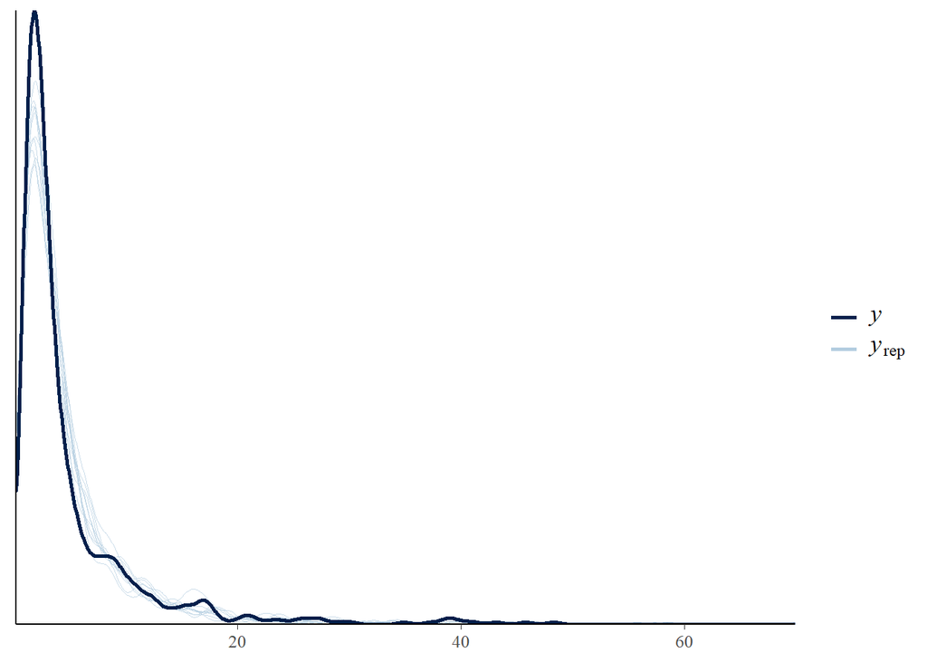

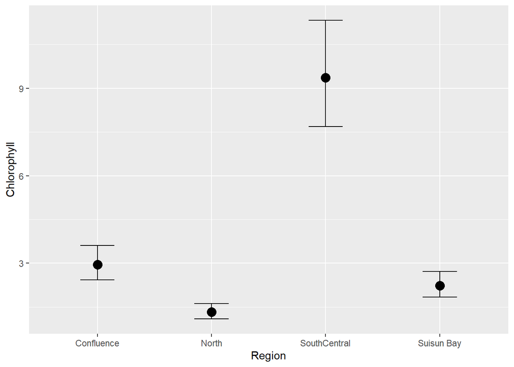

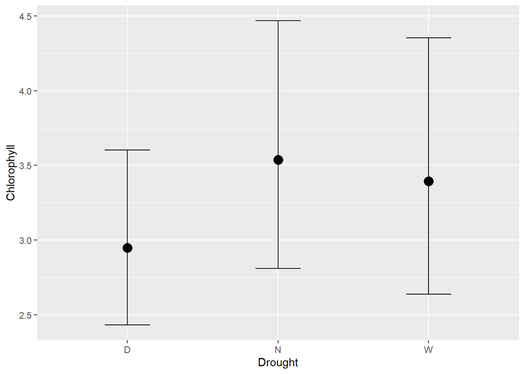

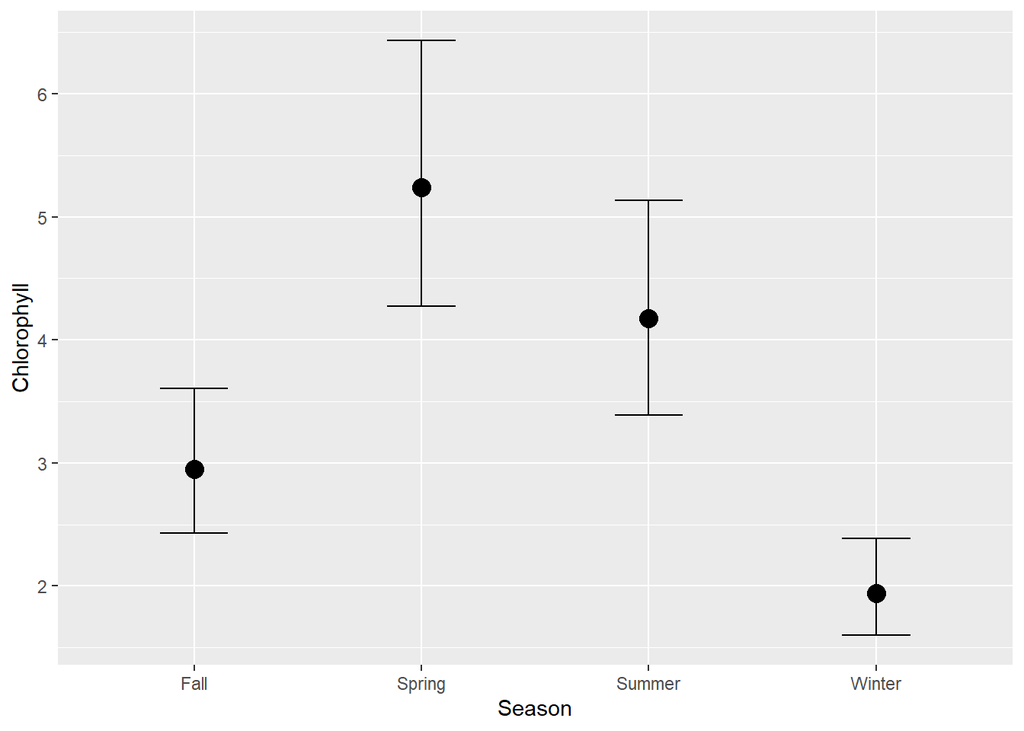

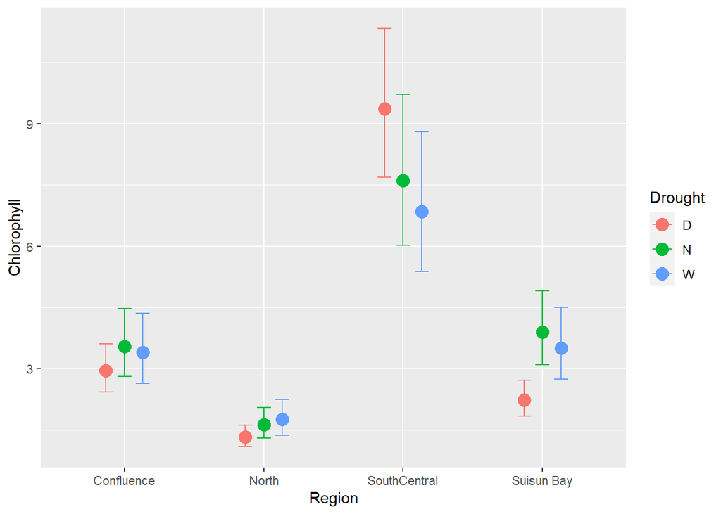

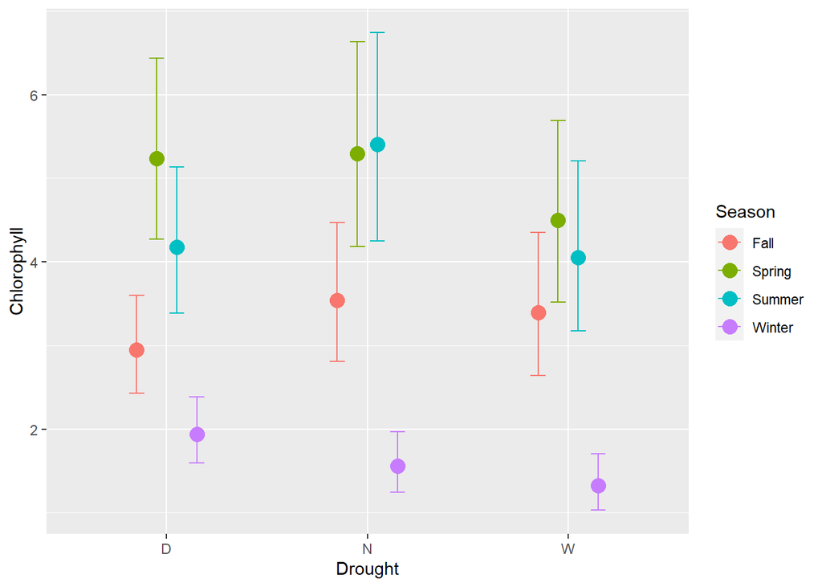

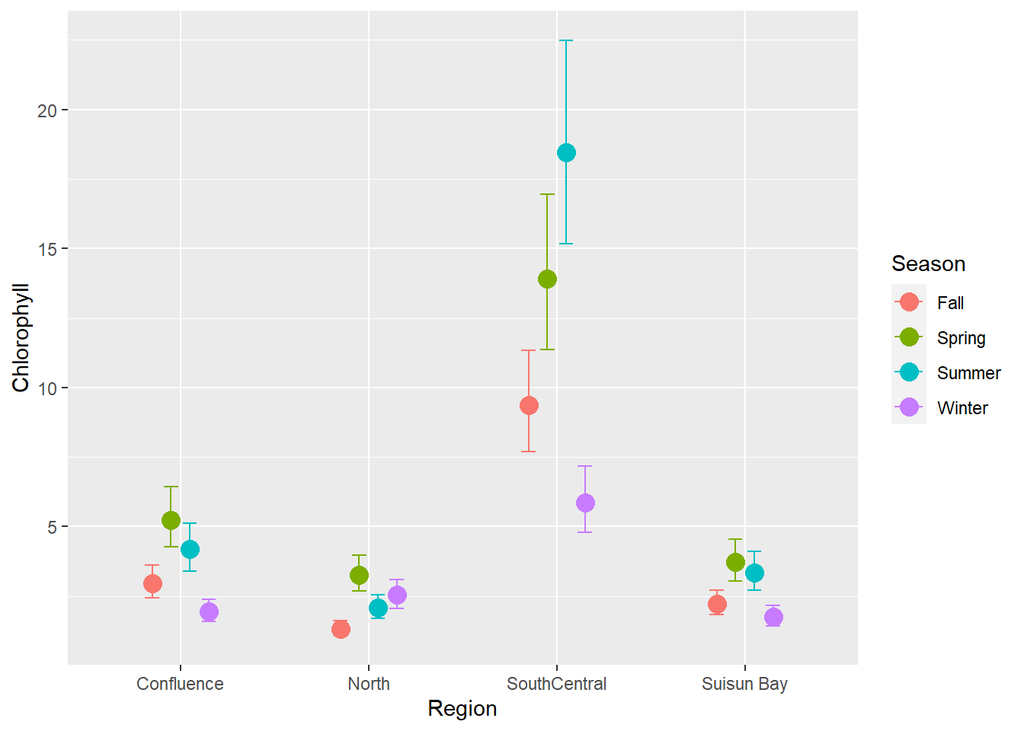

```r
cex = conditional_effects(chlb, ask = FALSE)
cex
```